# More Examples of Linear Model with Interactions

# More examples Multiple linear model with interactions

A simple linear model is where $Y_i$ represents the value of what is generally known as the *response variable* on the $ith$ individual and that $x_i$ represents the individual’s values on what is most often called an *explanatory variable* (or regressors). In general in R we can write the interaction term as the product of the regressors that we are studying and that we are interested in their interaction: $x_i:x_j$. For a multiple linear model with two regressors and interactions for one individual, the equation looks like:

$$\tt Y=\beta_0 + \beta_1 x_1 + \beta_2
x_2 + \beta_3 x_1 x_2$$

## HSAUR2 example of multiple linear regression

Weather modification, of cloud seeding, is the treatment of individual clouds of storm systems with various organic or inorganic materials in the hope of achieving an increase in rainfall. For the following example these variables were measured:

**seeding** a factor indicating whether seeding action occurred (yes or no)  
**time** number of days after the first day of the experiment  
**sne** measured suitability criterion, denoted *S-Ne*  
**cloudcover** the percentage of the cloud cover in the experimental area, measured using radar  
**prewetness** the total rainfall in the target area one hour before seeding (in cubic meters $\times 10^7$). **echomotion** a factor showing wether the the radar echo was moving or stationary  
**rainfall** the amount of rain in the taget area in cubic meters $\times10^7$

This are only additive linear terms to explain a random response variable $Y$ and the adjusted parameters are the $\beta_i$ of the independent variables or predictors. These variables are random too. They can be numbers and factors. Example of multiple linear regression using the *clouds data* in the database clouds from HSAUR books.

```r
data("clouds", package = "HSAUR2")
head(clouds)
```

```
##   seeding time  sne cloudcover prewetness echomotion rainfall
## 1      no    0 1.75       13.4      0.274 stationary    12.85
## 2     yes    1 2.70       37.9      1.267     moving     5.52
## 3     yes    3 4.10        3.9      0.198 stationary     6.29
## 4      no    4 2.35        5.3      0.526     moving     6.11
## 5     yes    6 4.25        7.1      0.250     moving     2.45
## 6      no    9 1.60        6.9      0.018 stationary     3.61
```

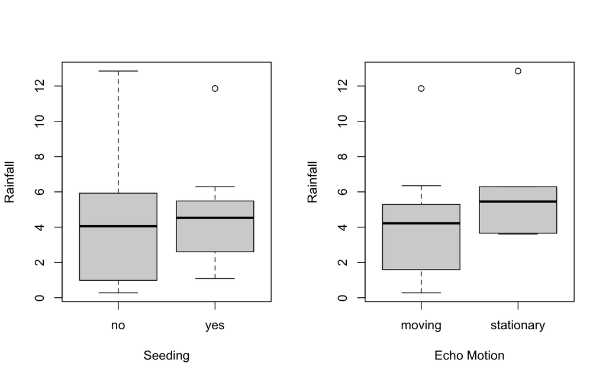

```r
# looking the data for rainfall
layout(matrix(1:2, ncol = 2))
boxplot(rainfall ~ seeding, ylab = "Rainfall", xlab = "Seeding", data = clouds)
boxplot(rainfall ~ echomotion, ylab = "Rainfall", xlab = "Echo Motion", data = clouds)
```

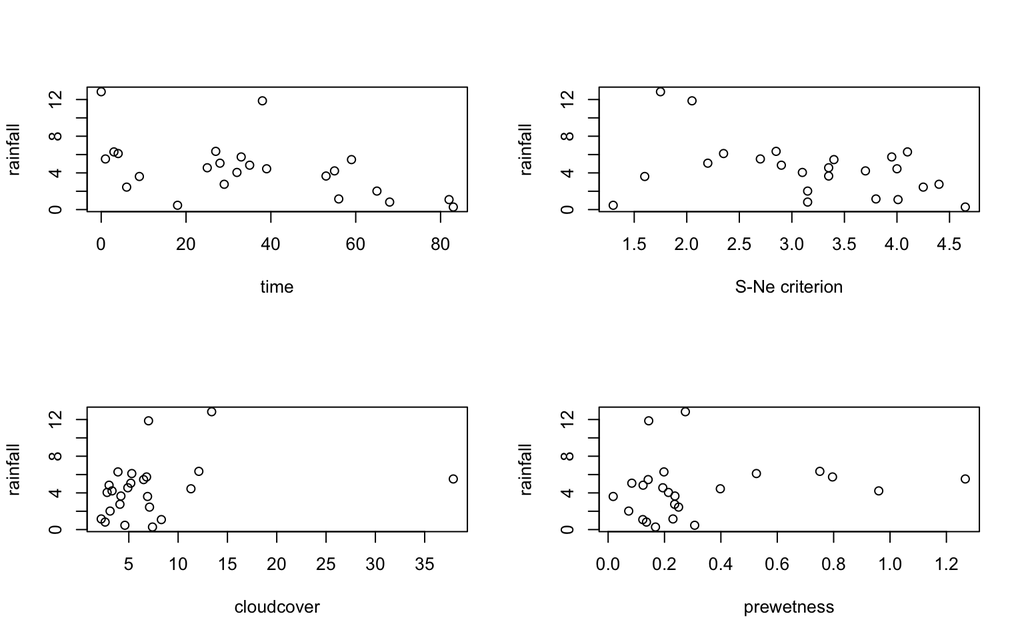

```r
#
layout(matrix(1:4, nrow = 2))
plot(rainfall ~ time, data = clouds)
plot(rainfall ~ cloudcover, data = clouds)
plot(rainfall ~ sne, data = clouds, xlab="S-Ne criterion")
plot(rainfall ~ prewetness, data = clouds)
```

To estimate a multiple linear model with interactions is estimated by defining the variable `clouds_formula` and passing it to the `lm` function. the results of the model fitting is an object of class `lm` for which we use `summary()` to list the resulting model parameters.

```r
clouds_formula <- rainfall ~ seeding + seeding:(sne+cloudcover+prewetness+echomotion) + time
clouds_lm <- lm(clouds_formula, data = clouds)
summary(clouds_lm)
```

```
##
## Call:
## lm(formula = clouds_formula, data = clouds)
##
## Residuals:
##     Min      1Q  Median      3Q     Max
## -2.5259 -1.1486 -0.2704  1.0401  4.3913
##
## Coefficients:
##                                 Estimate Std. Error t value Pr(>|t|)
## (Intercept)                     -0.34624    2.78773  -0.124  0.90306
## seedingyes                      15.68293    4.44627   3.527  0.00372 **
## time                            -0.04497    0.02505  -1.795  0.09590 .
## seedingno:sne                    0.41981    0.84453   0.497  0.62742
## seedingyes:sne                  -2.77738    0.92837  -2.992  0.01040 *
## seedingno:cloudcover             0.38786    0.21786   1.780  0.09839 .
## seedingyes:cloudcover           -0.09839    0.11029  -0.892  0.38854
## seedingno:prewetness             4.10834    3.60101   1.141  0.27450
## seedingyes:prewetness            1.55127    2.69287   0.576  0.57441
## seedingno:echomotionstationary   3.15281    1.93253   1.631  0.12677
## seedingyes:echomotionstationary  2.59060    1.81726   1.426  0.17757
## ---
## Signif. codes:  0 '***' 0.001 '**' 0.01 '*' 0.05 '.' 0.1 ' ' 1
##
## Residual standard error: 2.205 on 13 degrees of freedom
## Multiple R-squared:  0.7158, Adjusted R-squared:  0.4972
## F-statistic: 3.274 on 10 and 13 DF,  p-value: 0.02431
```

```r
Xstar <- model.matrix(clouds_formula, data = clouds)
attr(Xstar, "contrasts")
```

```
## $seeding
## [1] "contr.treatment"
##
## $echomotion
## [1] "contr.treatment"
```

```r
layout(matrix(1:1, nrow = 1))
# to list the betas* with the:
betaStar <- coef(clouds_lm)
betaStar
```

```
##                     (Intercept)                      seedingyes
##                     -0.34624093                     15.68293481
##                            time                   seedingno:sne
##                     -0.04497427                      0.41981393
##                  seedingyes:sne            seedingno:cloudcover
##                     -2.77737613                      0.38786207
##           seedingyes:cloudcover            seedingno:prewetness
##                     -0.09839285                      4.10834188
##           seedingyes:prewetness  seedingno:echomotionstationary
##                      1.55127493                      3.15281358
## seedingyes:echomotionstationary
##                      2.59059513
```

An important plot that will help understand the interaction of *seeding* with *S-Ne criterion* and if its interaction affects rainfall is the following.

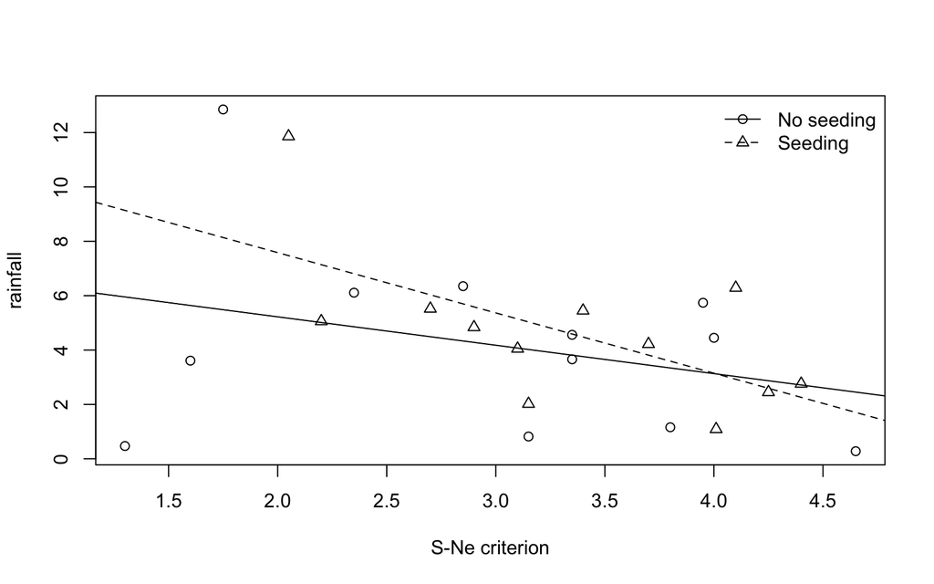

```r
psymb <- as.numeric(clouds$seeding)
# because seeding in yes, no

plot(rainfall ~ sne, pch = psymb, xlab = "S-Ne criterion", data = clouds)
abline(lm(rainfall ~ sne, subset = seeding == "no", data = clouds))
abline(lm(rainfall ~ sne, subset = seeding == "yes", data = clouds), lty = 2)
legend("topright", legend = c("No seeding", "Seeding"), pch = 1:2, lty = 1:2, bty = "n")
```

```r
#

# and the Covariant matrix Cov(beta*) with:
VbetaStar <- vcov(clouds_lm)

# Where the square roots of the diagonal elements are the standart errors
sqrt(diag(VbetaStar))
```

```
##                     (Intercept)                      seedingyes
##                      2.78773403                      4.44626606
##                            time                   seedingno:sne
##                      0.02505286                      0.84452994
##                  seedingyes:sne            seedingno:cloudcover
##                      0.92837010                      0.21785501
##           seedingyes:cloudcover            seedingno:prewetness
##                      0.11028981                      3.60100694
##           seedingyes:prewetness  seedingno:echomotionstationary
##                      2.69287308                      1.93252592
## seedingyes:echomotionstationary
##                      1.81725973
```

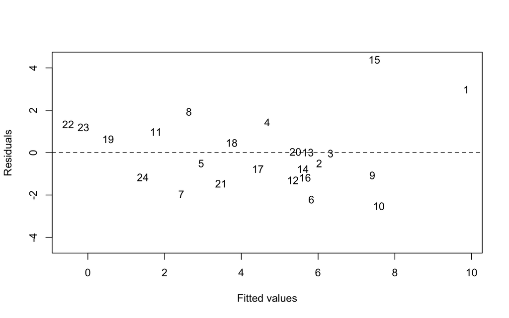

```r
clouds_resid <- residuals(clouds_lm)
clouds_fitted <- fitted(clouds_lm)

# residuals and the fitted values can be used to construct diagnostic plot
plot(clouds_fitted, clouds_resid, xlab = "Fitted values", ylab = "Residuals", type = "n", ylim = max(abs(clouds_resid)) * c(-1, 1))
abline(h = 0, lty = 2)
textplot(clouds_fitted, clouds_resid, words = rownames(clouds), new = FALSE)
```

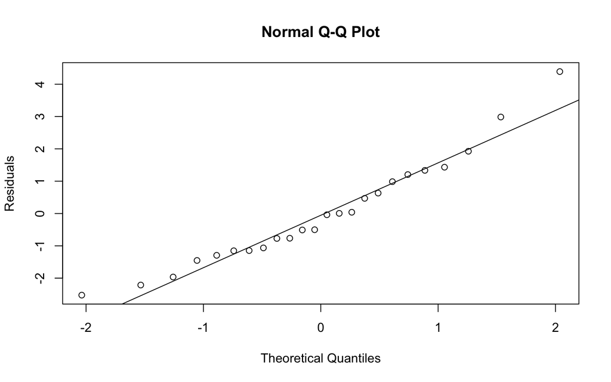

```r
qqnorm(clouds_resid, ylab = "Residuals")
qqline(clouds_resid)
```

These plots are estimated in R directly by applying the `plot` command to the fitted model, in this case `plot(clouds_lm)`.

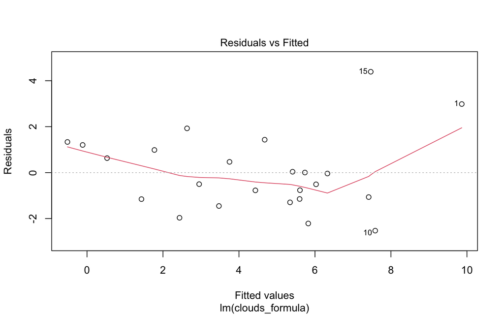

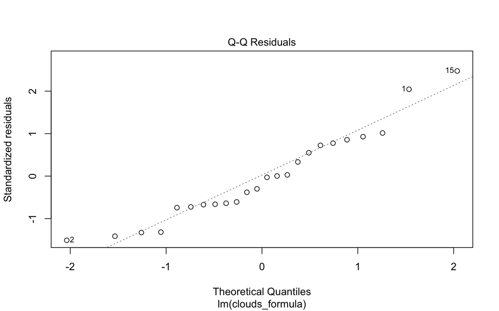

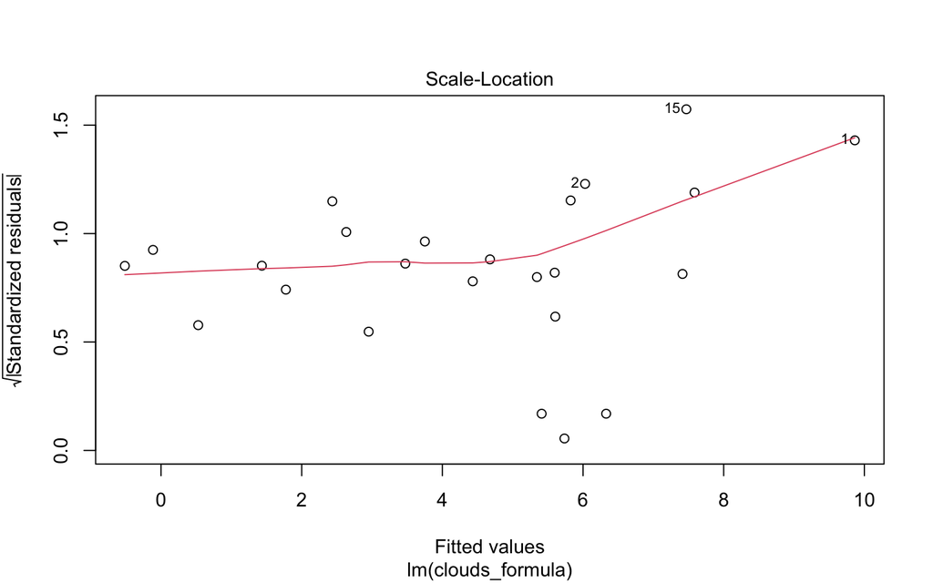

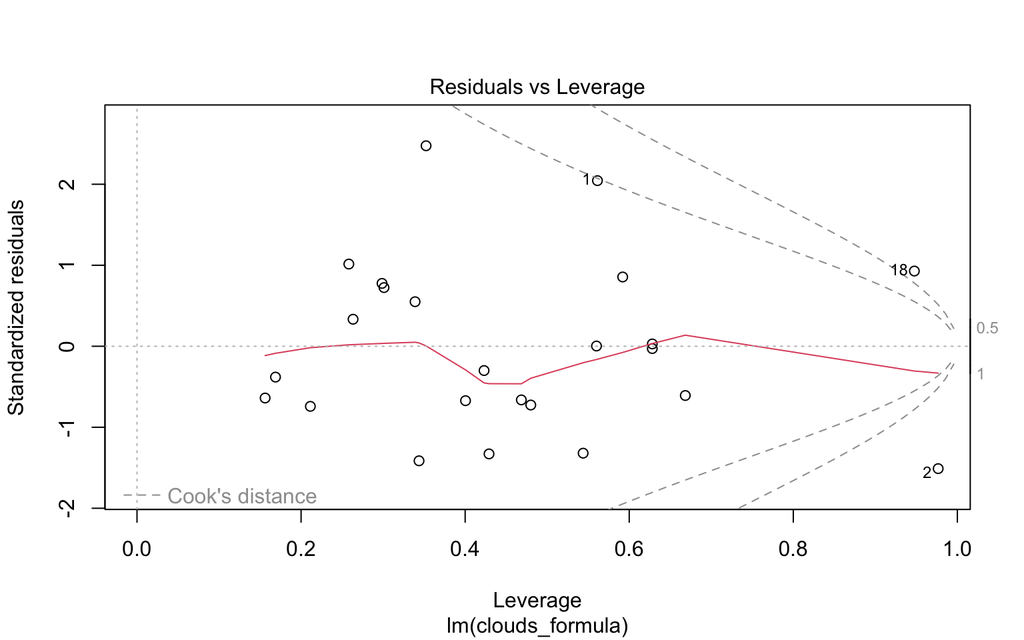

```r
plot(clouds_lm)
```

An important diagnostic for a linear model is the Cook’s distance $D_k$ This statistic is defined as.
$$D_k = \frac{1}{(q-1)\hat{\sigma}^2}\sum_{i=1}^n(\hat{y}_{i(k)} - y_i)^2$$
where observations that have an undue influence on the estimated regression coefficients have a relative large Cook’s distance.